# R Notebook

# Q6 Regional

When looking at regional tourism, what insights can we gain? Where are our visitors from? How do they differ in the money they spend, nights they spend in Scotland, or number of visits they do?

```r
regional %>%
  count(feature_code)
```

| feature_code | n |
| --- | --- |
| S12000005 | 81 |
| S12000006 | 81 |
| S12000008 | 81 |
| S12000010 | 81 |
| S12000011 | 81 |
| S12000013 | 81 |
| S12000014 | 81 |
| S12000017 | 81 |
| S12000018 | 81 |
| S12000019 | 81 |

[output cut: 23 more lines]

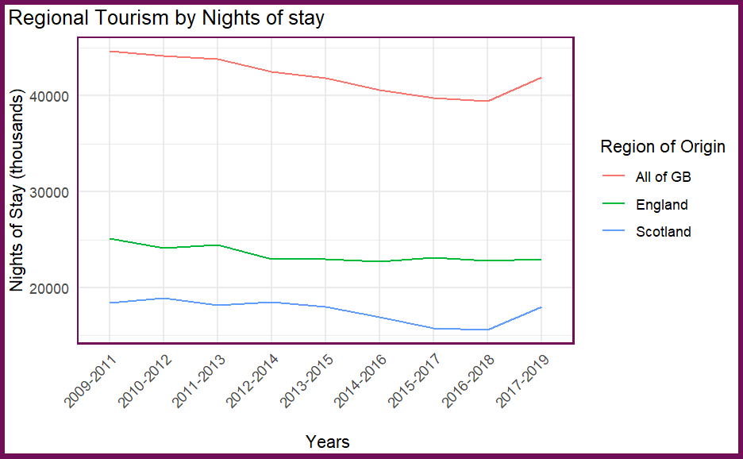

```r
regional %>%
  filter(feature_code == "S92000003",
         units == "Thousand Nights") %>%
  ggplot(aes(x = date_code, y = value))+
  geom_line(aes(colour = region_of_residence, group = region_of_residence))+
  labs(title = "Regional Tourism by Nights of stay",
       y = "Nights of Stay (thousands)",
       x = "\n Years",
       color = "Region of Origin")+
  theme(axis.text.x = element_text(angle = 45, hjust = 1))+
      theme_minimal()+
  theme(panel.border = element_rect(colour = "#700e57", fill=NA, size=1),
        plot.background = element_rect(colour = "#700e57", fill=NA, size=3),
        plot.caption = element_text(hjust = 0, face= "italic"),
        plot.title.position = "plot", #NEW parameter. Apply for subtitle too.
        plot.caption.position =  "plot",
        axis.text.x = element_text(angle = 45, hjust=1))
```

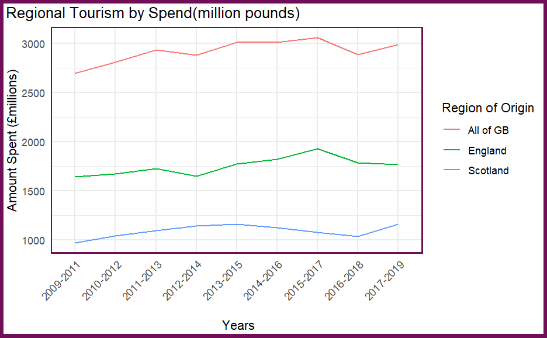

```r
regional %>%
  filter(feature_code == "S92000003",
         units == "million pounds (GBP)") %>%
  ggplot(aes(x = date_code, y = value))+
  geom_line(aes(colour = region_of_residence, group = region_of_residence))+
  labs(title = "Regional Tourism by Spend(million pounds)",
       y = "Amount Spent (£millions)",
       x = "\n Years",
       color = "Region of Origin")+
  theme(axis.text.x = element_text(angle = 45, hjust = 1))+
      theme_minimal()+
  theme(panel.border = element_rect(colour = "#700e57", fill=NA, size=1),
        plot.background = element_rect(colour = "#700e57", fill=NA, size=3),
        plot.caption = element_text(hjust = 0, face= "italic"),
        plot.title.position = "plot", #NEW parameter. Apply for subtitle too.
        plot.caption.position =  "plot",
        axis.text.x = element_text(angle = 45, hjust=1))
```

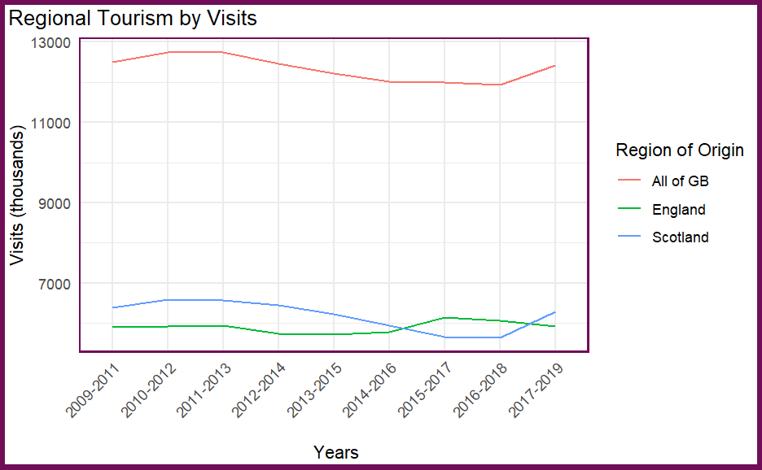

```r
regional %>%
  filter(feature_code == "S92000003",
         units == "Thousand Visits") %>%
  ggplot(aes(x = date_code, y = value))+
  geom_line(aes(colour = region_of_residence, group = region_of_residence))+
  labs(title = "Regional Tourism by Visits",
       y = "Visits (thousands)",
       x = "\n Years",
       color = "Region of Origin")+
  theme(axis.text.x = element_text(angle = 45, hjust = 1))+
      theme_minimal()+
  theme(panel.border = element_rect(colour = "#700e57", fill=NA, size=1),
        plot.background = element_rect(colour = "#700e57", fill=NA, size=3),
        plot.caption = element_text(hjust = 0, face= "italic"),
        plot.title.position = "plot", #NEW parameter. Apply for subtitle too.
        plot.caption.position =  "plot",
        axis.text.x = element_text(angle = 45, hjust=1))
```

> can say English have slightly fewer visits but longers stays which makes sense. Also spend more - accommodation spend, overnights etc

```r
head(regional)
```

| feature_code | date_code | units | value | region_of_residence | breakdown_of_domestic_tourism | local_authority |
| --- | --- | --- | --- | --- | --- | --- |
| S12000039 | 2016-2018 | million pounds (GBP) | 8 | England | Expenditure | West Dunbartonshire |
| S12000039 | 2015-2017 | Thousand Nights | 140 | All of GB | Nights | West Dunbartonshire |
| S12000039 | 2015-2017 | million pounds (GBP) | 8 | England | Expenditure | West Dunbartonshire |
| S12000039 | 2017-2019 | Thousand Nights | 76 | England | Nights | West Dunbartonshire |
| S12000039 | 2009-2011 | Thousand Visits | 68 | Scotland | Visits | West Dunbartonshire |
| S12000039 | 2016-2018 | Thousand Nights | 59 | Scotland | Nights | West Dunbartonshire |

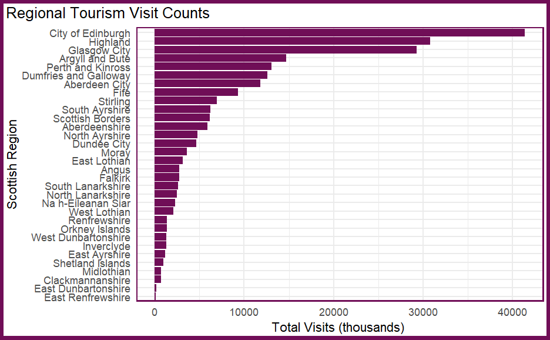

```r
regional %>%
  filter(units == "Thousand Visits", feature_code != "S92000003") %>%
  group_by(local_authority) %>%
  summarise(total_visits = sum(value)) %>%
  ggplot(aes(x = reorder(local_authority,total_visits), y = total_visits))+
  geom_col(fill = "#700e57")+
  coord_flip()+
    theme_minimal()+
  theme(panel.border = element_rect(colour = "#700e57", fill=NA, size=1),
        plot.background = element_rect(colour = "#700e57", fill=NA, size=3),
        plot.caption = element_text(hjust = 0, face= "italic"),
        plot.title.position = "plot", #NEW parameter. Apply for subtitle too.
        plot.caption.position =  "plot")+
  labs(title = "Regional Tourism Visit Counts",
       y = "Total Visits (thousands) ",
       x = "Scottish Region")
```

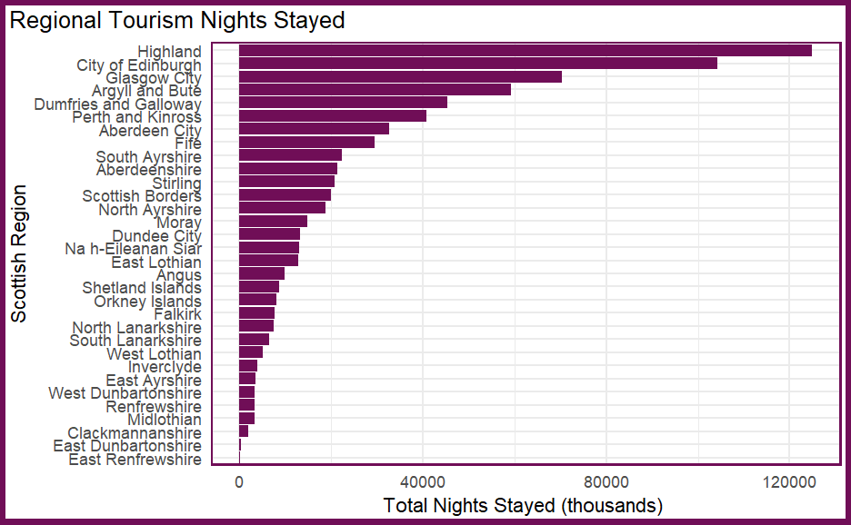

```r
regional %>%
  filter(units == "Thousand Nights", feature_code != "S92000003") %>%
  group_by(local_authority) %>%
  summarise(total_visits = sum(value)) %>%
  ggplot(aes(x = reorder(local_authority,total_visits), y = total_visits))+
  geom_col(fill = "#700e57")+
  coord_flip()+
    theme_minimal()+
  theme(panel.border = element_rect(colour = "#700e57", fill=NA, size=1),
        plot.background = element_rect(colour = "#700e57", fill=NA, size=3),
        plot.caption = element_text(hjust = 0, face= "italic"),
        plot.title.position = "plot", #NEW parameter. Apply for subtitle too.
        plot.caption.position =  "plot")+
  labs(title = "Regional Tourism Nights Stayed",
       y = "Total Nights Stayed (thousands) ",
       x = "Scottish Region")
```

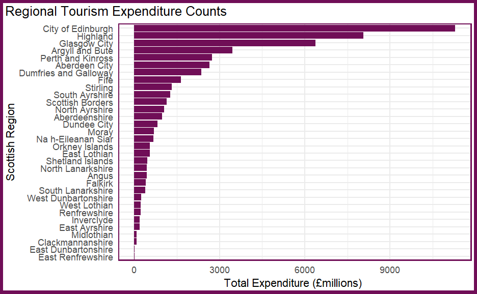

```r
regional %>%
  filter(units == "million pounds (GBP)", feature_code != "S92000003") %>%
  group_by(local_authority) %>%
  summarise(total_visits = sum(value)) %>%
  ggplot(aes(x = reorder(local_authority,total_visits), y = total_visits))+
  geom_col(fill = "#700e57")+
  coord_flip()+
  theme_minimal()+
  theme(panel.border = element_rect(colour = "#700e57", fill=NA, size=1),
        plot.background = element_rect(colour = "#700e57", fill=NA, size=3),
        plot.caption = element_text(hjust = 0, face= "italic"),
        plot.title.position = "plot", #NEW parameter. Apply for subtitle too.
        plot.caption.position =  "plot")+
  labs(title = "Regional Tourism Expenditure Counts",
       y = "Total Expenditure (£millions) ",
       x = "Scottish Region")
```

> edinburgh glasgow and highland the big three. But highland overtakes on nights stayed suggesting cities more popular for shorter breaks or as part of a travel holiday. WOuldnt be opening a b&B in east ren

#Q7 Accomodation Type What type of accommodation is most popular? Is there a difference by location?

```r
accom %>%
  count(accommodation_type_and_occupancy)
```

| accommodation_type_and_occupancy | n |
| --- | --- |
| Caravan & Camping Parks - Pitch Occupancy | 81 |
| Guest House/B&B - Room Occupancy | 108 |
| Hostels - Bed Occupancy | 81 |
| Hotels - Room Occupancy | 135 |
| Self Catering - Unit Occupancy | 63 |

```r
accom %>%
  filter(date_code == 2019, accom != "All") %>%
  arrange(desc(value))
```

| date_code | value | accommodation_type_and_occupancy | weekday_weekend | size_of_accommodation | location | accom |
| --- | --- | --- | --- | --- | --- | --- |
| 2019 | 87.93 | Guest House/B&B - Room Occupancy | All | Rooms: 11-25 | All | Rooms: 11-25 |
| 2019 | 81.98 | Hotels - Room Occupancy | All | All | Accessible Small Towns | Accessible Small Towns |
| 2019 | 78.38 | Hotels - Room Occupancy | All | Rooms: 26-50 | All | Rooms: 26-50 |
| 2019 | 75.57 | Hotels - Room Occupancy | All | All | Large Urban Areas | Large Urban Areas |
| 2019 | 74.36 | Hotels - Room Occupancy | All | Rooms: greater than 100 | All | Rooms: greater than 100 |
| 2019 | 74.35 | Hotels - Room Occupancy | All | Rooms: 51-100 | All | Rooms: 51-100 |
| 2019 | 72.51 | Hotels - Room Occupancy | Weekday | All | All | Weekday |
| 2019 | 70.86 | Guest House/B&B - Room Occupancy | All | All | Large Urban Areas | Large Urban Areas |
| 2019 | 70.24 | Hotels - Room Occupancy | Weekend | All | All | Weekend |
| 2019 | 68.74 | Hotels - Room Occupancy | All | All | Other Urban Areas | Other Urban Areas |

[output cut: 37 more lines]

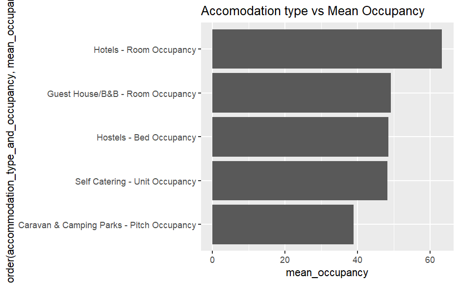

```r
accom %>%
  filter(accom != "All") %>%
  group_by(accommodation_type_and_occupancy) %>%
  summarise(mean_occupancy = mean(value)) %>%
  ggplot(aes(x = reorder(accommodation_type_and_occupancy, mean_occupancy), y = mean_occupancy))+
  geom_col()+
  coord_flip()+
  labs(title = "Accomodation type vs Mean Occupancy",
       )
```

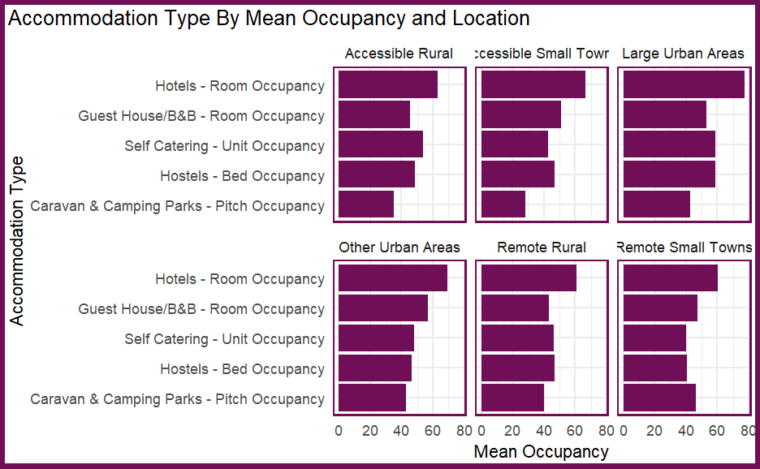

```r
accom %>%
  filter(accom != "All", location != "All") %>%
  group_by(accommodation_type_and_occupancy, location) %>%
  summarise(mean_occupancy = mean(value)) %>%
  ggplot(aes(x = reorder(accommodation_type_and_occupancy, mean_occupancy), y = mean_occupancy))+
  geom_col(fill = "#700e57")+
  coord_flip()+
  labs(title = "Accommodation Type By Mean Occupancy and Location",
       y = "Mean Occupancy",
       x = "Accommodation Type")+
    theme_minimal()+
    theme(panel.border = element_rect(colour = "#700e57", fill=NA, size=1),
        plot.background = element_rect(colour = "#700e57", fill=NA, size=3),
        plot.caption = element_text(hjust = 0, face= "italic"),
        plot.title.position = "plot", #NEW parameter. Apply for subtitle too.
        plot.caption.position =  "plot")+
  facet_wrap( ~ location)
```

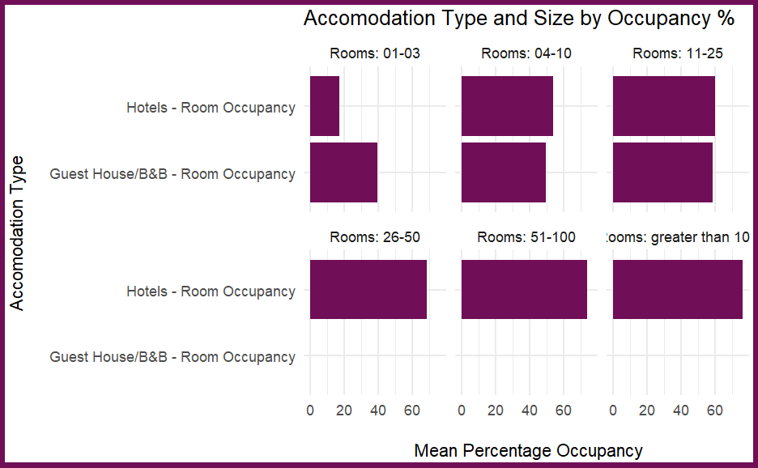

```r
accom %>%
  filter(accom != "All", size_of_accommodation != "All") %>%
  group_by(accommodation_type_and_occupancy, size_of_accommodation) %>%
  summarise(mean_occupancy = mean(value)) %>%
  ggplot(aes(x = reorder(accommodation_type_and_occupancy, mean_occupancy), y = mean_occupancy))+
  geom_col(fill = "#700e57")+
  coord_flip()+
  labs(title = "Accomodation Type and Size by Occupancy %",
       y = "\n Mean Percentage Occupancy",
       x = "Accomodation Type \n")+
  theme_minimal()+
  theme(plot.background = element_rect(colour = "#700e57", fill=NA, size=3))+
  facet_wrap( ~ size_of_accommodation)
```

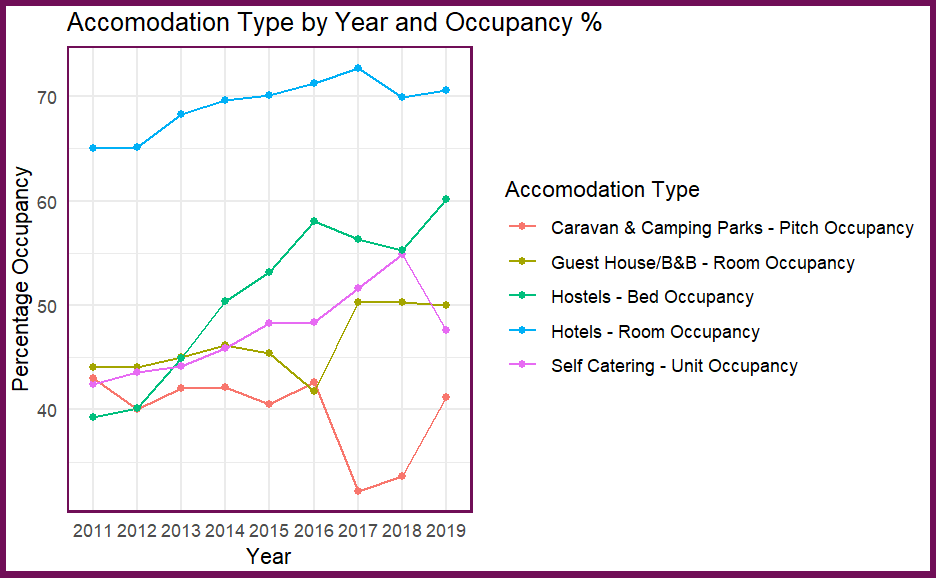

```r
accom %>%
  filter(accom == "All") %>%
  ggplot(aes(x = date_code, y = value, colour = accommodation_type_and_occupancy))+
  geom_line()+
  geom_point()+
  scale_x_discrete(limits = (accom$date_code))+
  labs(title = "Accomodation Type by Year and Occupancy %",
       x = "Year",
       y = "Percentage Occupancy")+
  theme_minimal()+
  theme(panel.border = element_rect(colour = "#700e57", fill=NA, size=1),
        plot.background = element_rect(colour = "#700e57", fill=NA, size=3))+
  labs(color='Accomodation Type')
```

• How have general tourism rates changed over time? > Feel like this has been answered on a question by question basis. Do a summary graph here of expenditure and Visits?

# International

```
Did you mean `limits = factor(...)` or `scale_*_continuous()`?
```

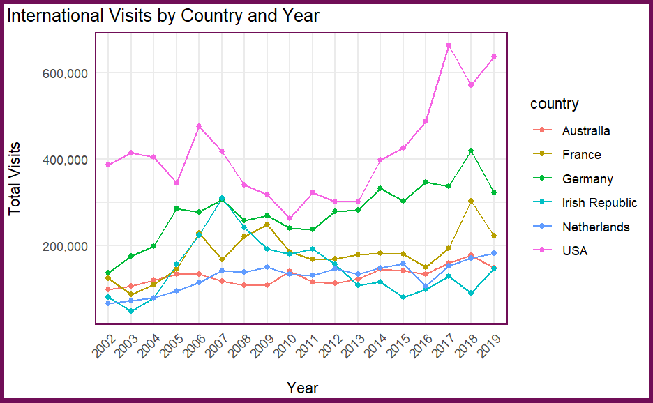

```r
inter %>%
  filter(country %in% top_6_visitors) %>%
  group_by(country, year) %>%
  summarise(total_visits = (sum(visits_000s)*1000)) %>%
  ggplot(aes(x= year, y = total_visits, colour = country))+
  geom_line()+
  geom_point()+
  scale_y_continuous(labels = comma)+
  scale_x_discrete(limits = (inter$year))+
  theme(axis.text.x = element_text(angle = 45, hjust = 1))+
  labs(title = "International Visits by Country and Year",
       x = "\n Year",
       y = "Total Visits\n")+
  theme_minimal()+
  theme(panel.border = element_rect(colour = "#700e57", fill=NA, size=1),
        plot.background = element_rect(colour = "#700e57", fill=NA, size=3),
        plot.caption = element_text(hjust = 0, face= "italic"),
        plot.title.position = "plot", #NEW parameter. Apply for subtitle too.
        plot.caption.position =  "plot",
        axis.text.x = element_text(angle = 45, hjust=1))
```

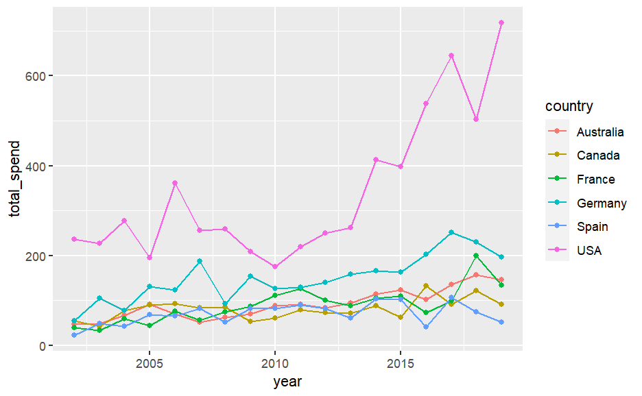

```r
# get a top 6
top_6_spend <- inter %>%
  group_by(country) %>%
  summarise(total_spend = sum(spend_m)) %>%
  slice_max(total_spend, n=6) %>%
  pull(country)

inter %>%
  filter(country %in% top_6_spend) %>%
  group_by(country, year) %>%
  summarise(total_spend = sum(spend_m)) %>%
  ggplot(aes(x= year, y = total_spend, colour = country))+
  geom_line()+
  geom_point()
```

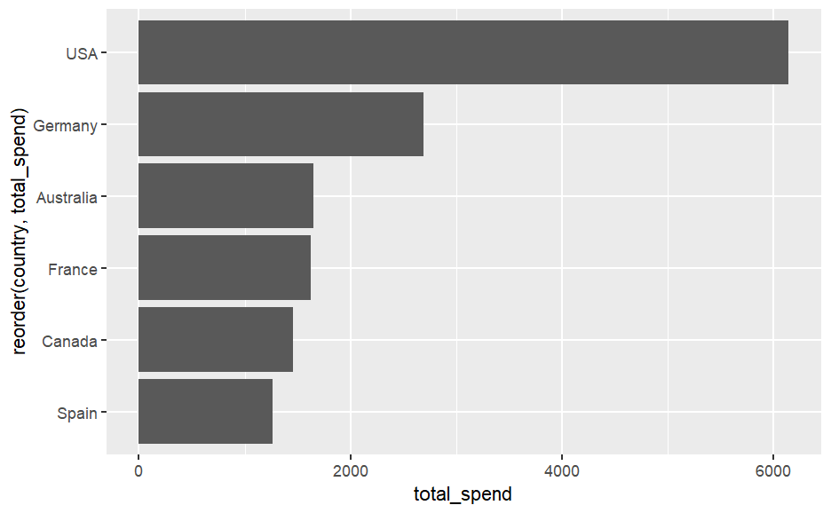

```r
inter %>%
  filter(country %in% top_6_spend) %>%
  group_by(country) %>%
  summarise(total_spend = sum(spend_m)) %>%
  ggplot(aes(x = reorder(country,total_spend), y = total_spend))+
  geom_col()+
  coord_flip()
```

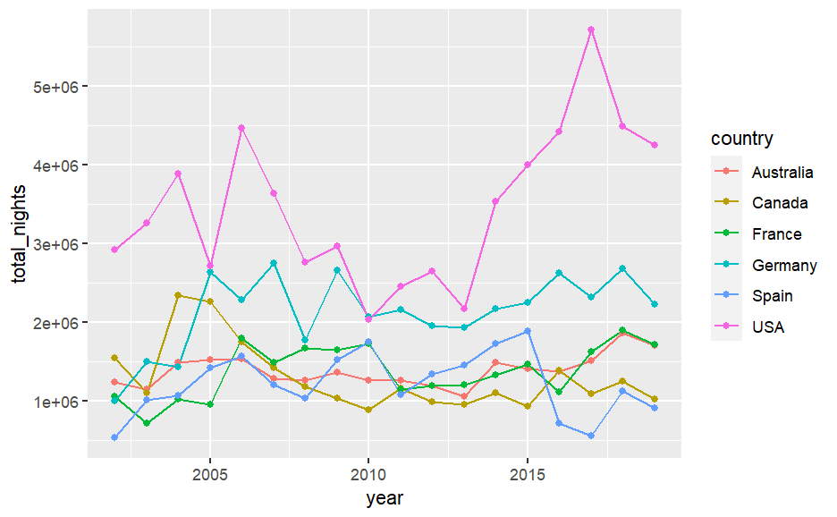

```r
# get a top 6
top_6_nights <- inter %>%
  group_by(country) %>%
  summarise(total_nights = sum(nights_000s)) %>%
  slice_max(total_nights, n=6) %>%
  pull(country)

inter %>%
  filter(country %in% top_6_nights) %>%
  group_by(country, year) %>%
  summarise(total_nights = (sum(nights_000s)*1000)) %>%
  ggplot(aes(x= year, y = total_nights, colour = country))+
  geom_line()+
  geom_point()
```

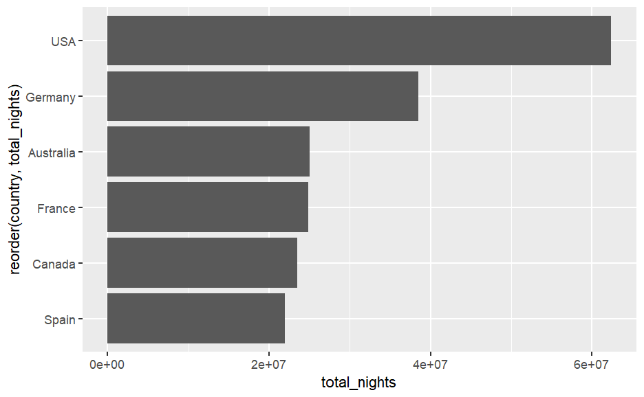

```r
inter %>%
  filter(country %in% top_6_nights) %>%
  group_by(country) %>%
  summarise(total_nights = (sum(nights_000s)*1000)) %>%
  ggplot(aes(x = reorder(country,total_nights), y = total_nights))+
  geom_col()+
  coord_flip()
```

is there any way to predict spending and visits for Visit Scotland? See python models # Comments

Better data recording! Team of marketers at the green welly doing surveys? Data is already summarised epecially the demographic table

Social Grade Description % HRP population (UK) AB Higher & intermediate managerial, administrative, professional occupations 22.17 C1 Supervisory, clerical & junior managerial, administrative, professional occupations 30.84 C2 Skilled manual occupations 20.94 DE Semi-skilled & unskilled manual occupations, Unemployed and lowest grade occupations 26.05

Household Reference Person – DEFINITION (source: ONS)

The concept of a Household Reference Person (HRP) was introduced in the 2001 Census (in common with other government surveys in 2001/2) to replace the traditional concept of the ‘head of the household’.

Unclear whether the use of “all of great britain” includes N Ireland? Technically GB is just england wales and scotland but it has been used to mean NI as well.

Domestic tourism statistics by region and year. All figures come from the Great Britain Tourism Survey (GBTS) and represent 3-year annual averages due to small sample sizes on regional level.

Data has already been summarised - would have been better to have had the original data

COVID going to wreck all this data

US in 2010 - what did we start putting in their coffee? Do that to everyone else!

2017 - was this effect of rough guide?

The pre summarised data didnt always add up to the totals we would expect in each dataset - worth reviewing this

Next: scrape twitter for tweets regarding visit scotland mentions better models with unsummarised data review data for accuracy - totals havent always added up better data collection!